# Behavioral Cloning Project

## 1. Files Submitted & Code Quality

### 1.1. Submission includes all required files and can be used to run the simulator in autonomous mode

My project includes the following files:

- model.py containing the script to create and train the model
- drive.py for driving the car in autonomous mode. it's a just resubmit the original drive.py
- model.h5 containing a trained convolution neural network
- writeup_report.md and writeup_report.html summarizing the results
- video.mp4 revealing the model is available for track 1 and 2

### 1.2. Submission includes functional code

Using the Udacity provided simulator and my drive.py file, the car can be driven autonomously around both track 1 and 2 by executing

```bash
python drive.py model.h5
```

### 1.3. Submission code is usable and readable

The model.py file contains the code for training and saving the convolution neural network.  
The file shows the pipeline I used for training and validating the model, the generator to save memories when training and validating are executed with huge umber of dataset, the graph plot code to output the loss curve of each training and validation, and it contains comments to explain how the code works.

## 2. Model Architecture and Training Strategy

### 2.1. Feasibility study in model architectures

Before designing a model, I had tests on typical models explained in "Behavioral Cloning" lesson as follow.

1. flat model
2. LeNet model
3. NVIDIA model (PilotNet)

These models are defined as following:

#### Flat model

```
# flat model
model = Sequential()
model.add(Lambda(lambda x: (x / 255.0) - 0.5, input_shape=(160, 320, 3)))
model.add(Cropping2D(cropping=((70, 20), (0, 0))))
model.add(Flatten())
model.add(Dense(100))
model.add(Dropout(0.5))
model.add(Dense(50))
model.add(Dropout(0.5))
model.add(Dense(10))
model.add(Dropout(0.5))
model.add(Dense(1))
```

#### LeNet model

```
# LeNet model
model = Sequential()
model.add(Lambda(lambda x: (x / 255.0) - 0.5, input_shape=(160, 320, 3)))
model.add(Cropping2D(cropping=((70, 20), (0, 0))))
model.add(Convolution2D(20, 5, 5, subsample=(1, 1), activation='relu'))
model.add(MaxPooling2D((2, 2)))
model.add(Dropout(0.25))
model.add(Convolution2D(50, 5, 5, subsample=(1, 1), activation='relu'))
model.add(MaxPooling2D((2, 2)))
model.add(Dropout(0.25))
model.add(Flatten())
model.add(Dense(100, activation='relu'))
model.add(Dropout(0.5))
model.add(Dense(50, activation='relu'))
model.add(Dropout(0.5))
model.add(Dense(10, activation='relu'))
model.add(Dropout(0.5))
model.add(Dense(1))
```

#### NVIDIA model (PilotNet)

```
# NVIDIA model (PilotNet)
model = Sequential()
model.add(Lambda(lambda x: (x / 255.0) - 0.5, input_shape=(160, 320, 3)))
model.add(Cropping2D(cropping=((70, 20), (0, 0))))
model.add(Convolution2D(24, 5, 5, subsample=(2, 2), activation='relu'))
model.add(Convolution2D(36, 5, 5, subsample=(2, 2), activation='relu'))
model.add(Convolution2D(48, 5, 5, subsample=(2, 2), activation='relu'))
model.add(Convolution2D(64, 3, 3, activation='relu'))
model.add(Convolution2D(64, 3, 3, activation='relu'))
model.add(Flatten())
model.add(Dense(100))
model.add(Dense(50))
model.add(Dense(10))
model.add(Dense(1))
```

These three models are trained under the equal condition via following code and parameters.

```
# training code is as follows
model.compile(loss='mse', optimizer='adam')
history = model.fit(X_train, y_train, validation_split=0.2, shuffle=True, nb_epoch=20, verbose=2)
model.save('model.h5')
```

[output not shown]

All three models adopt multi camera inputs solution.  
Left and right camera images are loaded, and used as training datasets as following code.

```
import pandas as pd
df = pd.read_csv(args.csvfile, header=0)

images = []
measurements = []
for i, dat in df.iterrows():
    path = os.path.join(args.imgdir, dat[0])

    steering = float(dat[3])

    # center camera
    images.append(np.asarray(Image.open(os.path.join(args.imgdir, dat[0].strip()))))
    measurements.append(steering)
    # left camera
    images.append(np.asarray(Image.open(os.path.join(args.imgdir, dat[1].strip()))))
    measurements.append(steering + 0.2)
    # right camera
    images.append(np.asarray(Image.open(os.path.join(args.imgdir, dat[2].strip()))))
    measurements.append(steering - 0.2)

X_train = np.array(images)
y_train = np.array(measurements)
```

Following figures show training curves of each models.  
PilotNet is obviously overfitted, but its loss value is extremely smaller than other models.

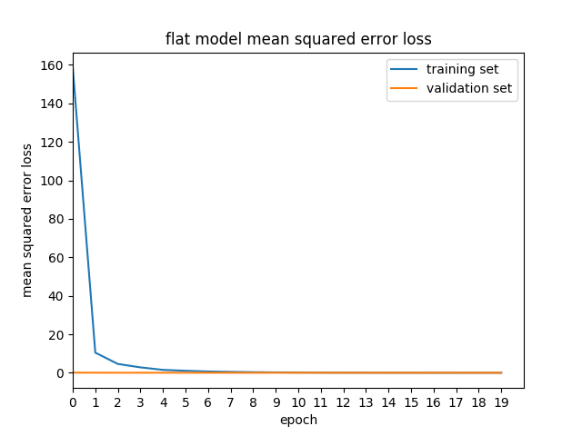

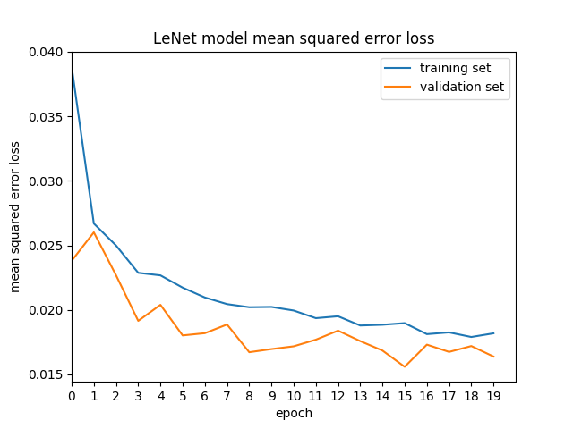

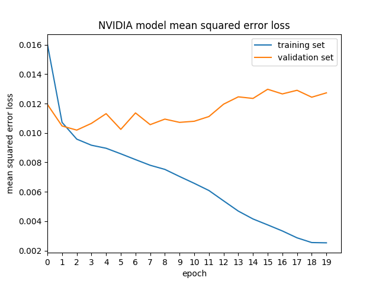

### 2.2. Attempts to reduce overfitting in the model

From the result of the feasibility study, I took PilotNet to apply into my project.  
Original PilotNet is as below. (my final model is described in the next section)

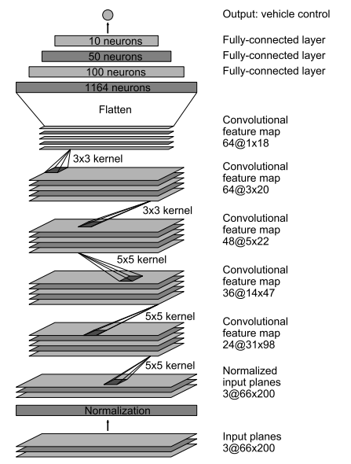

#### Adding dropout layers

To prevent overfitting, I had a study to estimate how dropout should be added into the model.

Following figures show learning curves of two ways adding Dropout layers.  
Left graph is a case that dropouts are inserted every after FC layers.  
Right graph is a case that dropouts are inserted every after FC layers and CNNs.

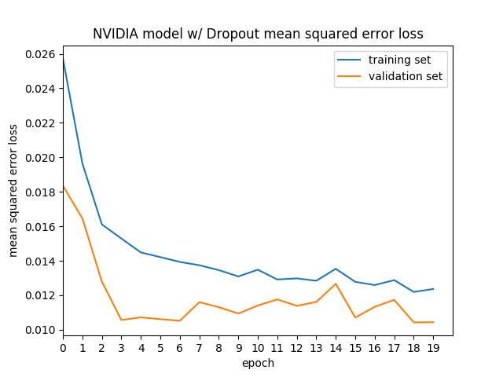

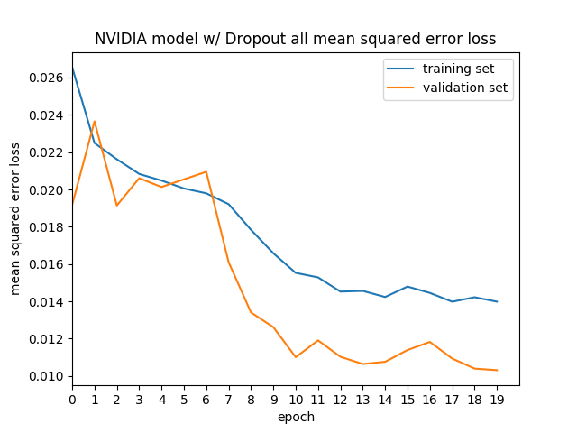

Some other studies said that adding dropouts into all after layers is effective. It is not so remarkable in this case, but I took 5 dropout model because more dropouts caused more fluency of training curve.

#### Shrinking PilotNet

This PilotNet implementation seems to be too large for our purpose, relative to the NVIDIA paper "Explaining How a Deep Neural Network Trained with End-to-End Learning Steers a Car".

On the other hand, both of the project and PilotNet have similar input image size, therefore the feature map of the model would work as well as PilotNet.

So I deceided to shrink only the fully-connected layers (dense layers) of the PilotNet to prevent overfitting.

### 2.3. Detail of the final model

Following table shows the detail of my final model.

[output not shown]

My final model consists of five convolution neural networks and two Fully connected networks.  
The geometry of the CNN layers are really similar to PilotNet, as the table above, therefore its feature maps are expected to work as well as PilotNet.

And the size of the two fully connected layers are far shrinked than PilotNet.  
It is also efficient to avoid overfitting.

Following figure shows my final model.

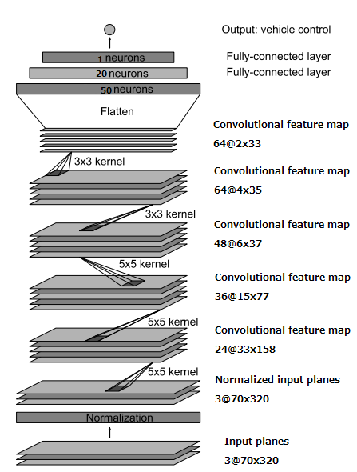

The model was trained and validated on different data sets to ensure that the model was not overfitting.  
Both of the dataset shuffled via "sklearn.utils.shuffle" function before training.

The model was tested by running it through the simulator and ensuring that the vehicle could stay on the track.

### 2.4. Model parameter tuning

The model used an adam optimizer, so the learning rate was not tuned manually.

### 2.5. Appropriate training data

#### Multi cameras use

I had a test beforehand to confirm potentialities of single camera use and multi cameras use.  
Following scene shows the car can run over at the sharp corner with uncertain curb, if input camera is single.

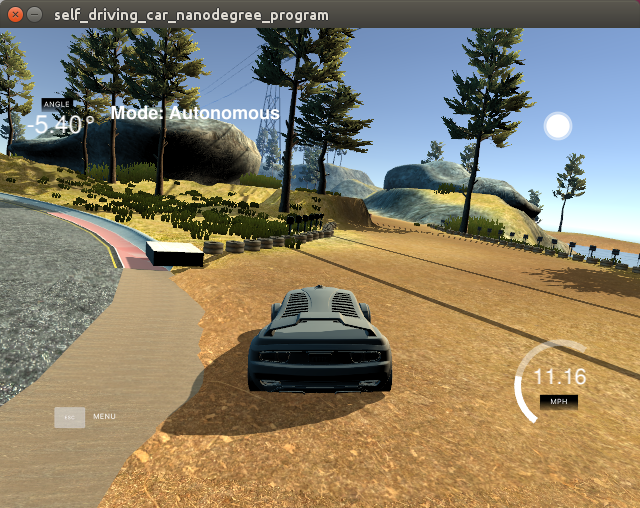

When the model was trained with multi cameras, the car never run over at the corner and keeps on the road of track 1 at least one hour.

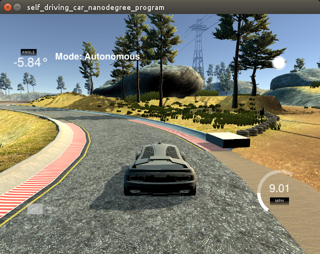

Here are the example images input from the three cameras.

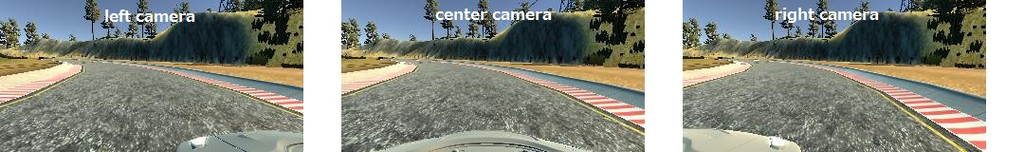

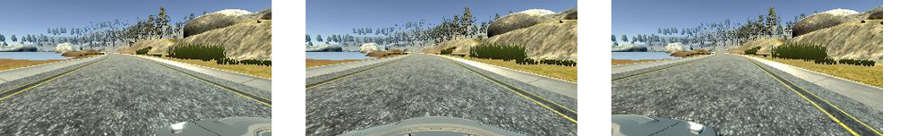

[figure not shown]

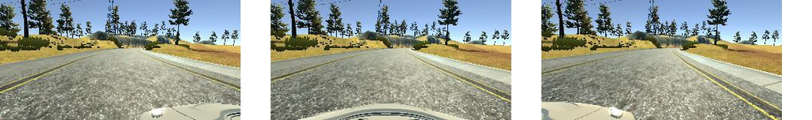

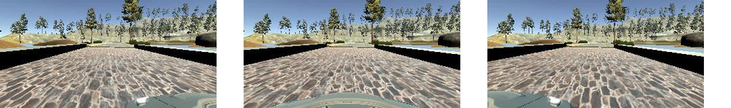

The multi input images are cropped at the first section of the final model like following pictures, although the actual input images are normalized before cropping.

[figure not shown]

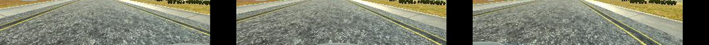

[figure not shown]

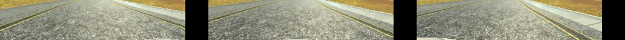

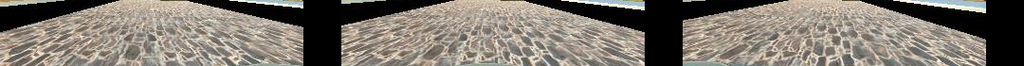

In the training process, left and right images are treated in similar ways with center image *expect their steering angle values* .  
It is a same method as the lesson showed us, but I set steer_offset to 0.3 after some studies. (actually this value weren't sensitive.)

```
# steer_offset is set to 0.3

# center camera
images.append(np.asarray(Image.open(os.path.join(args.imgdir, dat[0].strip()))))
angles.append(steering)
# left camera
images.append(np.asarray(Image.open(os.path.join(args.imgdir, dat[1].strip()))))
angles.append(steering + steer_offset)
# right camera
images.append(np.asarray(Image.open(os.path.join(args.imgdir, dat[2].strip()))))
angles.append(steering - steer_offset)
```

#### Making datasets for each track

Training curve of the provided dataset is as following.  
The final model works well and drives around track 1 after traininig with the dataset, but of course it is not adaptive to track 2.

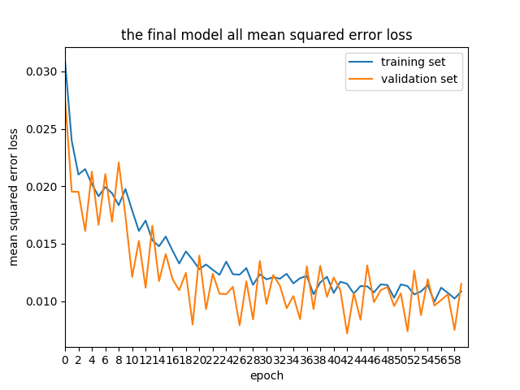

At first I made two dataset for each track 1 and 2.

Training curve of my datset for track 1 is as following.

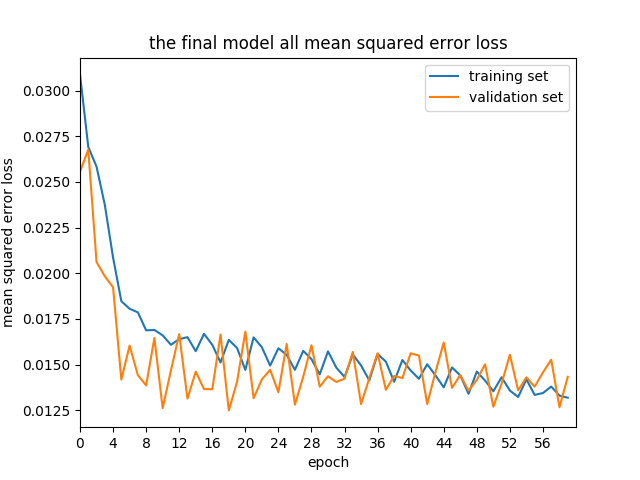

Training curve of my datset for track 2 is as following.

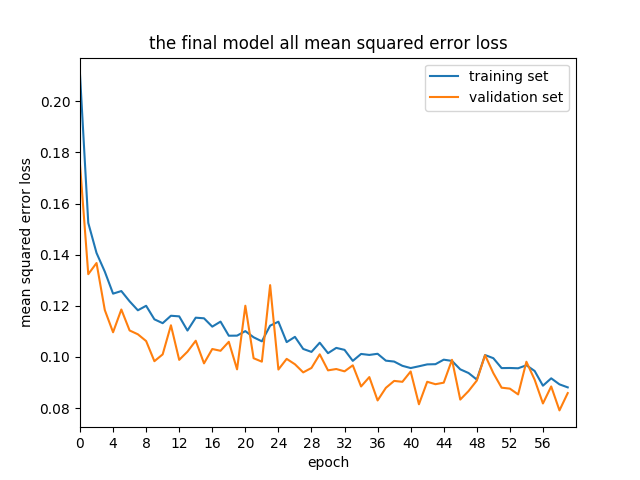

The two dataset were enough to train the final model to work for each track.  
And the car runs around the each track along the center of its road.

At track 2, I tried to make the car keep to the right lane.

#### Ensuring the compatibility with both track 1 and track 2

At first I tried simple unification of the two dataset, and it works for track 1 but not for track 2.  
So, until the model works well for the both two tracks, I augmented training data at every problematic curves.

For example, the car was sometimes caught in poles standing at the edge of the sharp corner as follows.

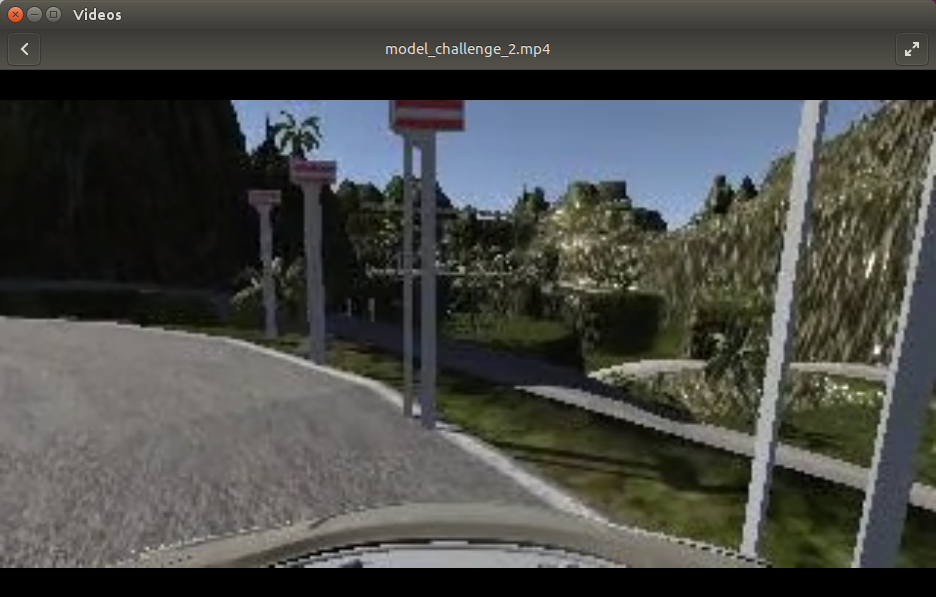

Then I added or replaced training images at the corner by the simulator as follows.

[figure not shown]

After many repetitions of such a operation, I got the final dataset that work well on the both tracks.  
Therefore the final dataset became very large.

Training curve of the final datset is as following.

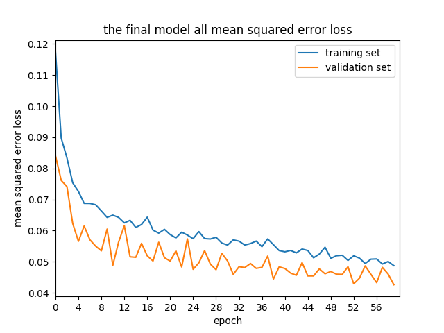

#### Augmenting dataset via mirrored images

To argment the dataset efficiently, I used mirrored images of center camera via following code.

```
 # flipped images
 # center camera
 images.append(np.fliplr(np.asarray(Image.open(os.path.join(args.imgdir, dat[0].strip())))))
 angles.append(-steering)
```

About left and right camera, I could not find a good way to arrange the offset value of the steering angle for their mirror images.  
So I did not use the both side cameras.

#### Generator implementation

I implemented generator to have a lot of dataset as following code.  
I could train the final model with a huge dataset, thus the generator reduced the memory consumption.

```
def generator(samples, batch_size=32, steer_offset=0.3):
    num_samples = len(samples)
    while 1:  # Loop forever so the generator never terminates
        sklearn.utils.shuffle(samples, replace=False)
        for offset in range(0, num_samples, batch_size):
            batch_samples = samples[offset:offset+batch_size]

            images = []
            angles = []
            for dat in batch_samples:
                steering = float(dat[3])
                # center camera
                images.append(np.asarray(Image.open(os.path.join(args.imgdir, dat[0].strip()))))
                angles.append(steering)
                # left camera
                images.append(np.asarray(Image.open(os.path.join(args.imgdir, dat[1].strip()))))
                angles.append(steering + steer_offset)
                # right camera
                images.append(np.asarray(Image.open(os.path.join(args.imgdir, dat[2].strip()))))
                angles.append(steering - steer_offset)

                #
                # flipped images
                #
                # center camera
                images.append(np.fliplr(np.asarray(Image.open(os.path.join(args.imgdir, dat[0].strip())))))
                angles.append(-steering)

            X_train = np.array(images)
            y_train = np.array(angles)
            yield sklearn.utils.shuffle(X_train, y_train)
```

## Conclusion

PilotNet developed by NVIDIA was quite effective to end-to-end-learning.

I designed my CNN model by means of shrinking PilotNet and adding dropout layers in it. And the model was strengthened by three camera input.

Then I made dataset for the model to drive around both track 1 and 2. Though The dataset became far larger than twice of the provided dataset, I could complete it.

EOF